# homework-part1-gan

### Generating human faces with Adversarial Networks

[figure not shown]

This time we'll train a neural net to generate plausible human faces in all their subtlty: appearance, expression, accessories, etc. 'Cuz when us machines gonna take over the Earth, there won't be any more faces left. We want to preserve this data for future iterations. Yikes...

Based on https://github.com/Lasagne/Recipes/pull/94 .

```python
#!L
from yfile import download_from_yadisk
import os

TARGET_DIR = '.'
FILENAME = "celeba.zip"

if not os.path.exists(os.path.join(TARGET_DIR, FILENAME)):
    # we are going to download 1.4 gb file, downloading will take some time
    download_from_yadisk(
        short_url='https://disk.yandex.ru/d/QErNx-MoC-2Y6Q',
        filename=FILENAME,
        target_dir=TARGET_DIR
    )

    # alternative way:
    #from gfile import download_list
    #download_list(url=https://drive.google.com/file/d/1lwn2JMwWNGloGvyzKUOcewT8JqP1ICoW,
    #               filename=FILENAME, target_dir=TARGET_DIR)

filesize = os.path.getsize(os.path.join(TARGET_DIR, FILENAME))
GB = 2**30
assert filesize > 1 * GB, "{filesize} is too small, something wrong with downloading"
```

```python
#!L:bash
!unzip celeba.zip
```

```python
#!L
import matplotlib.pyplot as plt
%matplotlib inline
import numpy as np
plt.rcParams.update({'axes.titlesize': 'small'})
import os
os.environ['CUDA_VISIBLE_DEVICES'] = '2'
import torch, torch.nn as nn
import torch.nn.functional as F
from torch.utils.data import Dataset, DataLoader

import torchvision
from torchvision.utils import make_grid

use_cuda = torch.cuda.is_available()

print("Torch version:", torch.__version__)
if use_cuda:
    print("Using GPU")
else:
    print("Not using GPU")
```

```
Torch version: 2.8.0+cu128
Using GPU
```

### Prepare Dataset

```python
#!L
class CropCelebA64:

    def __call__(self, pic):
        new_pic = pic.crop((15, 40, 178 - 15, 218 - 30))
        return new_pic

    def __repr__(self):
        return self.__class__.__name__ + '()'
```

```python
#!L

# Note that for simplicity we reduce the number of channels to 1
# But if you want to be hardcore feel free to comment .Grayscale :)

train_dataset = torchvision.datasets.CelebA(
    root='celeba',
    split='train',
    transform=torchvision.transforms.Compose([
        CropCelebA64(),
        torchvision.transforms.Resize(64),
        torchvision.transforms.RandomHorizontalFlip(),
        torchvision.transforms.ToTensor(),

        torchvision.transforms.Grayscale()
    ]),
)

IMG_SHAPE = tuple(train_dataset[0][0].shape)
```

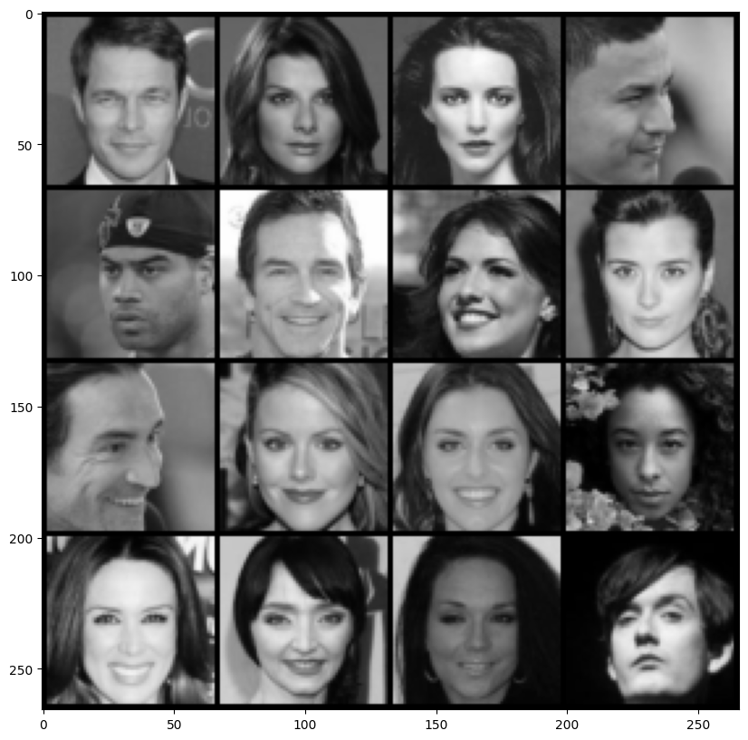

```python
#!L
# print some images
samples = torch.stack([train_dataset[i][0] for i in range(32, 48)], dim=0)

plt.figure(figsize=(10, 10))
plt.imshow(make_grid(samples, nrow=4).permute(1, 2, 0))
plt.show()
```

# Generative adversarial nets 101

[figure not shown]

Deep learning is simple, isn't it?

- build some network that generates a face (small image)
- make up a **measure** of **how good this face is**
- optimize with gradient descent :)

The only problem is: how can we engineers tell well-generated faces from bad? And i bet you we won't ask a designer for help.

**If we can't tell good faces from bad, we delegate it to yet another neural network!**

That makes the two of them:

- __G__enerator - takes random noize for inspiration and tries to generate a face sample.
  - Let's call him **G**(z), where z is a gaussian noize.
- __D__iscriminator - takes a face sample and tries to tell if it's great or fake.
  - Predicts the probability of input image being a **real face**
  - Let's call him **D**(x), x being an image.
  - **D(x)** is a predition for real image and **D(G(z))** is prediction for the face made by generator.

Before we dive into training them, let's construct the two networks.

```python
#!L
def sample_noise_batch(batch_size):
    noise = torch.randn(batch_size, CODE_SIZE)
    return noise.cuda() if use_cuda else noise.cpu()

class Reshape(nn.Module):
    def __init__(self, shape):
        nn.Module.__init__(self)
        self.shape = shape

    def forward(self,input):
        return input.view(self.shape)
```

```python
#!L
CODE_SIZE = 128 # Size of z noise vector; feel free to change it

generator = nn.Sequential()

## YOUR CODE - create architecture for discriminator
## Note: please start simple. You can start with the layers below, but you are more than welcome to change it

generator.add_module('linear1', nn.Linear(CODE_SIZE, 4*8*8))
generator.add_module('act1', nn.ELU())
generator.add_module('reshape1', Reshape([-1, 4, 8, 8]))

generator.add_module('conv1', nn.ConvTranspose2d(4, 64, kernel_size=4, stride=2, padding=1)) # B x 32 x 16 x 16
generator.add_module('norm1', nn.BatchNorm2d(64))
generator.add_module('act2', nn.ReLU())

##TODO: define next layers

generator.add_module('conv2', nn.ConvTranspose2d(64, 128, kernel_size=4, stride=2, padding=1)) # B x 64 x 32 x 32
generator.add_module('norm2', nn.BatchNorm2d(128))
generator.add_module('act3', nn.ReLU())

generator.add_module('conv2,5', nn.ConvTranspose2d(128, 128, kernel_size=1)) # B x 64 x 32 x 32
generator.add_module('norm2,5', nn.BatchNorm2d(128))
generator.add_module('act3,5', nn.ReLU())

generator.add_module('conv3', nn.ConvTranspose2d(128, 64, kernel_size=4, stride=2, padding=1)) # B x 64 x 64 x 64
generator.add_module('norm3', nn.BatchNorm2d(64))
generator.add_module('act4', nn.ReLU())

generator.add_module('conv5', nn.ConvTranspose2d(64, 1, kernel_size=1)) # B x 3 x 64 x 64

generator.add_module('final_act', nn.Sigmoid())



if use_cuda: generator.cuda()
generator.compile(mode="default", fullgraph=True, dynamic=False)
```

```python
print(sum([p.numel() for p in generator.parameters()]))
```

```
316865
```

```python
#!L
generated_data = generator(sample_noise_batch(5))
assert tuple(generated_data.shape)[1:] == IMG_SHAPE, "generator must output an image of shape %s, but instead it produces %s"%(IMG_SHAPE, tuple(generated_data.shape)[1:])
```

### Discriminator

```python
#!L
def sample_data_batch(batch_size):
    idxs = np.random.choice(np.arange(len(train_dataset)), size=batch_size)
    batch = torch.stack([train_dataset[idx][0] for idx in idxs], dim=0)
    return batch.cuda() if use_cuda else batch.cpu()

# a special module that converts [batch, channel, w, h] to [batch, units]
class Flatten(nn.Module):
    def forward(self, input):
        return input.view(input.shape[0], -1)
```

```python
#!L
discriminator = nn.Sequential()

## YOUR CODE - create convolutional architecture for discriminator
## Note: please start simple. A few convolutions & poolings would do, inception/resnet is an overkill


discriminator.add_module('conv1', nn.Conv2d(1, 32, kernel_size=4, stride=2, padding=1))  # B x 32 x 32 x 32
discriminator.add_module('act1', nn.LeakyReLU(0.2, inplace=True))
discriminator.add_module('drop1', nn.Dropout2d(0.2))

discriminator.add_module('conv2', nn.Conv2d(32, 64, kernel_size=4, stride=2, padding=1))  # B x 64 x 16 x 16
discriminator.add_module('act2', nn.LeakyReLU(0.2, inplace=True))
discriminator.add_module('drop2', nn.Dropout2d(0.2))

discriminator.add_module('conv3', nn.Conv2d(64, 64, kernel_size=4, stride=2, padding=1))  # B x 64 x 8 x 8
discriminator.add_module('act3', nn.LeakyReLU(0.2, inplace=True))
discriminator.add_module('drop3', nn.Dropout2d(0.2))

discriminator.add_module('conv4', nn.Conv2d(64, 64, kernel_size=4, stride=2, padding=1))  # B x 64 x 4 x 4
discriminator.add_module('act4', nn.LeakyReLU(0.2, inplace=True))
discriminator.add_module('drop4', nn.Dropout2d(0.2))

discriminator.add_module('flatten', nn.Flatten())
discriminator.add_module('disc_logit', nn.Linear(64 * 4 * 4, 1))  # B x 1

if use_cuda:
    discriminator.cuda()
discriminator.compile(mode="default", fullgraph=True, dynamic=False)
```

```python
print(sum([p.numel() for p in discriminator.parameters()]))
```

```
165601
```

```python
#!L
discriminator(sample_data_batch(4))
```

```
tensor([[-0.0062],
        [-0.0192],
        [-0.0062],
        [-0.0261]], device='cuda:0', grad_fn=<AddmmBackward0>)
```

# Training

We train the two networks concurrently:

- Train **discriminator** to better distinguish real data from **current** generator
- Train **generator** to make discriminator think generator is real
- Since discriminator is a differentiable neural network, we train both with gradient descent.

Training is done iteratively until discriminator is no longer able to find the difference (or until you run out of patience).

```python
#!L
def generator_loss(noise):
    """
    1. generate data given noise
    2. compute log P(real | gen noise)
    3. return generator loss (should be scalar)
    """
    generated_data = generator(noise)

    disc_on_generated_data = discriminator(generated_data)

    logp_gen_is_real = F.logsigmoid(disc_on_generated_data)

    loss = - torch.mean(logp_gen_is_real)

    return loss
```

```python
#!L
loss = generator_loss(sample_noise_batch(32))

print(loss)

assert len(loss.shape) == 0, "Loss must be scalar"
```

```
tensor(0.6992, device='cuda:0', grad_fn=<NegBackward0>)
```

```python
#!L
def discriminator_loss(real_data, generated_data):
    """
    1. compute discriminator's output on real & generated data
    2. compute log-probabilities of real data being real, generated data being fake
    3. return discriminator loss (scalar)
    """
    disc_on_real_data = discriminator(real_data)
    disc_on_fake_data = discriminator(generated_data)

    logp_real_is_real = F.logsigmoid(disc_on_real_data)
    logp_gen_is_fake = F.logsigmoid(-disc_on_fake_data)

    loss = - torch.mean(logp_real_is_real + logp_gen_is_fake)
    return loss
```

```python
#!L
loss = discriminator_loss(sample_data_batch(32),
                   generator(sample_noise_batch(32)))

print(loss)

assert len(loss.shape) == 0, "Loss must be scalar"
```

```
tensor(1.3875, device='cuda:0', grad_fn=<NegBackward0>)
```

### Auxilary functions

Here we define a few helper functions that draw current data distributions and sample training batches.

```python
#!L
def sample_images(nrow, ncol, sharp=False):
    images = generator(sample_noise_batch(batch_size=nrow*ncol))
    images = images.data.cpu().numpy().transpose([0, 2, 3, 1])
    if np.var(images)!=0:
        images = images.clip(0, 1)
    for i in range(nrow*ncol):
        plt.subplot(nrow,ncol,i+1)
        if sharp:
            plt.imshow(images[i], cmap="gray", interpolation="none")
        else:
            plt.imshow(images[i], cmap="gray")
    plt.show()

def sample_probas(batch_size):
    plt.title('Generated vs real data')
    D_real = torch.sigmoid(discriminator(sample_data_batch(batch_size)))
    generated_data_batch = generator(sample_noise_batch(batch_size))
    D_fake = torch.sigmoid(discriminator(generated_data_batch))

    plt.hist(D_real.data.cpu().numpy(),
             label='D(x)', alpha=0.5, range=[0,1])
    plt.hist(D_fake.data.cpu().numpy(),
             label='D(G(z))', alpha=0.5, range=[0,1])
    plt.legend(loc='best')
    plt.show()
```

### Training

Main loop. We just train generator and discriminator in a loop and draw results once every N iterations.

```python
#!L
# optimizers
disc_opt = torch.optim.Adam(discriminator.parameters(), lr=1e-4)
gen_opt = torch.optim.AdamW(generator.parameters(), lr=1e-4)
```

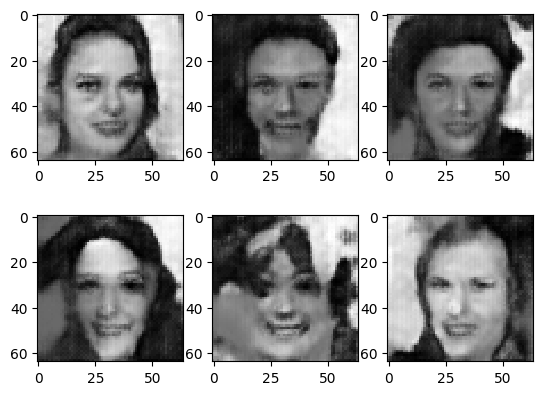

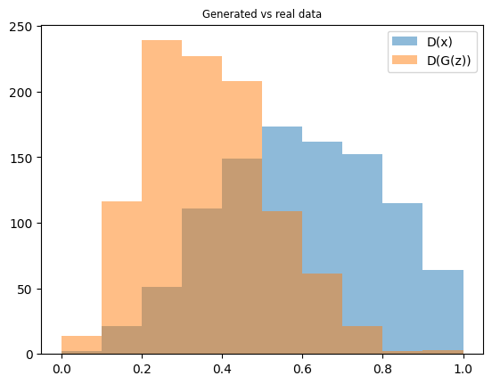

```
317it [00:45,  6.95it/s]
```

```python
from torch.amp import autocast, GradScaler
from IPython import display
from tqdm.auto import tqdm

scaler = GradScaler('cuda')

batch_size = 512
loader = DataLoader(train_dataset, batch_size=batch_size, shuffle=True, drop_last=True, num_workers=32)

for epoch in range(50):
    for iteration, (batch, _) in tqdm(enumerate(loader)):

        real_data = batch.cuda() if use_cuda else batch

        # Discriminator
        disc_opt.zero_grad()
        with torch.no_grad():
            noise = sample_noise_batch(batch_size)
            fake_data = generator(noise)

        with autocast(device_type='cuda', dtype=torch.bfloat16):
            loss = discriminator_loss(real_data, fake_data)

        scaler.scale(loss).backward()
        scaler.unscale_(disc_opt)
        torch.nn.utils.clip_grad_norm_(discriminator.parameters(), 1.)
        scaler.step(disc_opt)
        scaler.update()

        # Generator
        if iteration % 1 == 0:
            gen_opt.zero_grad()
            with autocast(device_type='cuda', dtype=torch.bfloat16):
                noise = sample_noise_batch(batch_size)
                loss = generator_loss(noise)

            scaler.scale(loss).backward()
            scaler.step(gen_opt)
            scaler.update()

        if iteration % 100 == 0:
            print(f"Epoch {epoch}, Iteration {iteration}")
            display.clear_output(wait=True)
            sample_images(2, 3, True)
            sample_probas(1000)
```

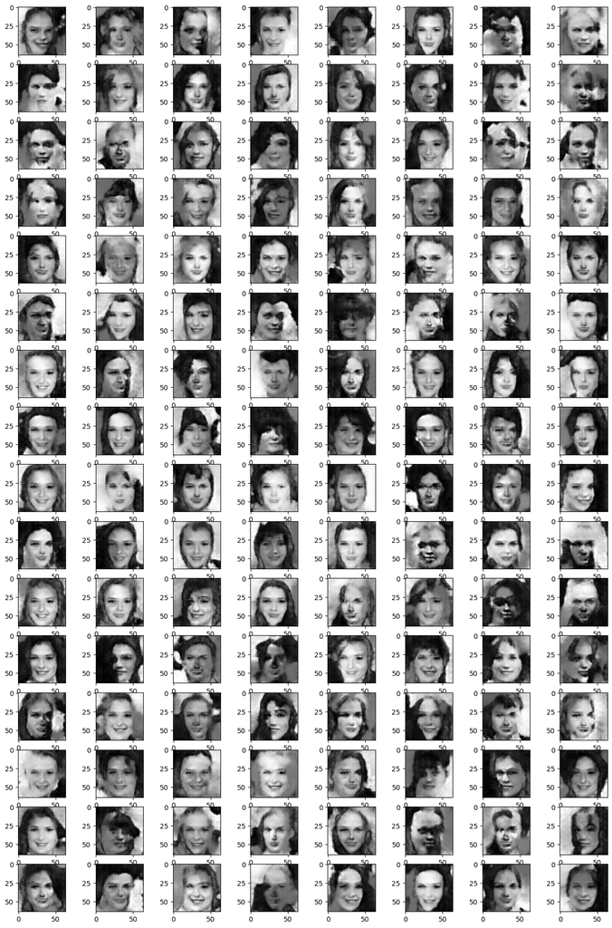

```python
#!L
plt.figure(figsize=[16, 24])
sample_images(16, 8)

# Note: a no-nonsense neural network should be able to produce reasonably good images after 15k iterations
# By "reasonably good" we mean "resembling a car crash victim" or better
```